# FigureYa184ranger

# Academic Citation

If you use this code in your work or research, we kindly request that you cite our publication:

Xiaofan Lu, et al. (2025). FigureYa: A Standardized Visualization Framework for Enhancing Biomedical Data Interpretation and Research Efficiency. iMetaMed. https://doi.org/10.1002/imm3.70005

# 需求描述

# Requirement

实现随机森林滑动窗口法。 Implement the random forest sliding window method.

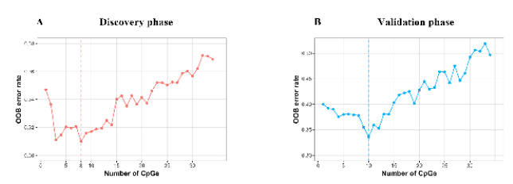

出自https://www.tandfonline.com/doi/full/10.1080/15592294.2019.1573066 fromhttps://www.tandfonline.com/doi/full/10.1080/15592294.2019.1573066

Figure 2. Ranger provides variable importance score (VIS) for each CpG probe for lung adenocarcinoma (LUAD) patients only in the discovery phase and the validation phase. “Out of bag (OOB)” error rate of top CpG probes in the model, when probes were included one by one based on their VIS ranks in the discovery (A) and the validation phase (B).

# 应用场景

# Application Scenarios

使用加权随机森林对生存数据降维，根据sliding windows sequential forward feature selection法筛选变量 The weighted random forest was used to reduce the dimension of the survival data, and the variables were screened according to the sliding windows sequential forward feature selection method

# 环境设置

# Environment Setup

```r
source("install_dependencies.R")
```

```
## Starting R package installation...
## ===========================================
##
## Installing CRAN packages...
## Package already installed: randomForest
## Package already installed: ranger
## Package already installed: survival
##
## ===========================================
## Package installation completed!
## You can now run your R scripts in this directory.
```

```r
library(ranger)
library(randomForest)
library(survival)
Sys.setenv(LANGUAGE = "en") #显示英文报错信息  # Display an English error message
options(stringsAsFactors = FALSE) #禁止chr转成factor  # prohibit chr from being converted to factor
```

自定义函数 Custom function

```r
# 显示进程
# Show Process
display.progress = function (index, totalN, breakN=20) {
  if ( index %% ceiling(totalN/breakN)  ==0  ) {
    cat(paste(round(index*100/totalN), "% ", sep=""))
  }
}
```

# 输入文件

# Input File

easy_input_expr.csv，表达矩阵。 easy_input_expr.csv, expressing matrix.

easy_input_cli.csv，临床信息。这两个文件跟FigureYa128Prognostic、FigureYa182RFSurv的一样，可以对比感受一下筛选效果。 easy_input_cli.csv, clinical information. These two documents are the same as those of FigureYa128Prognostic and FigureYa182RFSurv. You can compare them to get a sense of the screening effect.

```r
exp <- read.csv("easy_input_expr.csv",header = T,row.names = 1,check.names = F,stringsAsFactors = F)
cli <- read.csv("easy_input_cli.csv",header = T,row.names = 1,check.names = F,stringsAsFactors = F)

# 提取既有表达数据又有临床数据的样本
# Extract samples that have both expressive data and clinical data
com_sam <- intersect(colnames(exp),rownames(cli))
exp <- exp[,com_sam]
cli <- cli[com_sam,]

# 去除无表达的基因
# Remove unexpressed genes
exp <- exp[rowSums(exp) > 0,]

# 去除超过10%的样本表达量为0的基因
# Remove genes with expression levels of 0 from more than 10% of the samples
exp <- exp[rowSums(exp == 0) < 0.1 * ncol(exp),]

# 对数转化
# Logarithmic Transformation
exp <- log(exp + 1)
```

# 单变量cox模型筛选预后基因

# Univariate cox model for screening prognostic genes

```r
# 过滤出与OS有关的基因
# Filter out genes related to OS
cox.pcutoff <- 0.001
Coxoutput.OS <- NULL
for (i in 1:nrow(exp)) {
  display.progress(index = i,totalN = nrow(exp)) # 显示进度   # shows progress



  # 产生临时变量存储生存以及变量表达值
  # Generate temporary variables to store survival and variable expression values
  tmp <- data.frame(gene = as.numeric(exp[i,]),
                    OS.time = cli[,"OS.time"],
                    OS = cli[,"OS"],
                    stringsAsFactors = F)

  # 单变量cox比例风险模型
  # Univariate cox proportional hazards model
  cox <- coxph(Surv(OS.time, OS) ~ gene, data = tmp)
  coxSummary = summary(cox)

  # 生成cox结果数据框，包括基因名，风险比，z值，waldtest p值，以及HR置信区间
  # Generate cox result data frames, including gene names, hazard ratios, Z-values, waldtest P-values, and HR confidence intervals
  Coxoutput.OS=rbind.data.frame(Coxoutput.OS,data.frame(gene=rownames(exp)[i],
                                                        HR=as.numeric(coxSummary$coefficients[,"exp(coef)"]),
                                                        z=as.numeric(coxSummary$coefficients[,"z"]),
                                                        pvalue=as.numeric(coxSummary$coefficients[,"Pr(>|z|)"]),
                                                        lower=as.numeric(coxSummary$conf.int[,3]),
                                                        upper=as.numeric(coxSummary$conf.int[,4]),
                                                        stringsAsFactors = F),
                                stringsAsFactors = F)
}
```

```
## 5% 10% 15% 20% 25% 30%
```

```
## 35% 40% 45% 50% 55% 60% 65% 70% 75% 80% 85% 90% 95%
```

```r
write.csv(Coxoutput.OS,"univariate cox regression for gene filtering.csv",row.names = F,quote = F)
```

前面跟FigureYa182RFSurv的相同，下面就不一样了。 The front part is the same as that of Figure A182 RFSURV, but the bottom part is different.

# 加权随机森林进一步降维

# Weighted random forests further reduce dimensions

```r
gene.sel <- Coxoutput.OS[which(Coxoutput.OS$pvalue < cox.pcutoff),"gene"]
tmp <- exp[gene.sel,]
rownames(tmp) <- gsub("-","_",rownames(tmp)) # 防止出现“-”导致程序报错  # Prevent the occurrence of "-" from causing program errors
dt.rf <- cbind.data.frame(cli,t(tmp))
dt.rf <- dt.rf[,setdiff(colnames(dt.rf),"OS.time")] # 二分类分类树，结局考虑overall survival  # binary classification tree, with overall survival as the outcome

ntree <- 500
mtry <- floor(sqrt(length(gene.sel)))
weight <- 0.999999 # 算法要求无法取1但无限接近1，该参数表示变量被选择的概率，原文为100%。 #The algorithm requires that it cannot take 1 but is infinitely close to 1. This parameter represents the probability of the variable being selected, which is 100% in the original text.
seed <- 001

set.seed(seed) # 设置外部种子保证结果可重复 # Sets an external seed to ensure repeatability of the result
surv.rf <- ranger(formula = OS ~ .,
                  data = dt.rf,
                  num.trees = ntree,
                  mtry = mtry,
                  importance = "impurity",
                  split.select.weights = rep(weight,length(gene.sel)))
# 变量重要性按照降序排列
# Variable importance is arranged in descending order
var.imp <- sort(ranger::importance(surv.rf),decreasing = T)
```

# 逐步回归筛选变量

# Stepwise regression screens for variables

例文采用sliding windows sequential forward feature selection The example text adopts sliding windows sequential forward feature selection

简单思路为，根据重要性逐步纳入基因，每一次做当前基因组合下的随机森林并计算oob，取oob达到最小时的组合。 The simple idea is to gradually incorporate genes based on their importance. Each time, create a random forest under the current gene combination and calculate the oob. Take the combination with the smallest oob.

```r
ntree <- 500 # 树的数目，一般为500 #The number of trees is generally 500
nPerm <- 50 # 扰动次数，一般为50 # The number of disturbances is generally 50
var.now <- oob <- c()
for (var in names(var.imp)) {
  cat(var,"\n")
  set.seed(seed)
  var.now <- c(var.now,var)
  swsfs.dt <- dt.rf[,c("OS",var.now)]
  swsfs.dt$OS <- factor(swsfs.dt$OS)
  model_RF <- randomForest(OS ~ .,
                           data = swsfs.dt,
                           ntree = ntree,
                           nPerm = nPerm,
                           mtry = floor(sqrt(ncol(swsfs.dt))),
                           proximity = T,
                           importance = F)
  oob <- c(oob,model_RF$err.rate[ntree,1])
}
```

```
## KRT8P12
## AL031777.1
## GPC1
## SEPT5
## CCDC68
## TLE6
## MIR210HG
## AC016876.1
## NMRAL2P
## LRRN4
## CRACR2B
## NPM1P25
## MAN1B1
## WFDC10B
## ANKRD24
## PANX2
## AP2M1
## ST6GALNAC4P1
## ENO3
## AC084125.2
## TSPYL2
## AC010997.4
## ZSCAN5A
## GABRD
## INMT
## PLA2G15
## LINC01836
## QRFP
## LAMP5
## NOL3
## AC010973.2
## GBGT1
## KRT18P5
## ACTR1B
## DPH7
## AP001542.3
## CDC42SE2
## FOXS1
## DPP7
## AC133552.2
## IL20RB
## POFUT2
## DRD4
## AP006621.3
## PPFIA4
## AC068580.3
## LINC01909
## RNF138
## AC005076.1
## MC1R
## FOXH1
## ANAPC2
## AF274858.3
## PRMT2
## CCDC151
## RNF224
```

```r
names(oob) <- names(var.imp)
signature <- var.imp[1:which.min(oob)] # 取oob达到最小时候的gene组合作为最终signature  # Take the gene combination when oob reaches its minimum as the final signature
write.table(data.frame(signature = names(signature),importance = as.numeric(signature),stringsAsFactors = F),
            "signature with importance.txt",sep = "\t",row.names = F,quote = F)
```

# 开始画图

# Start drawing

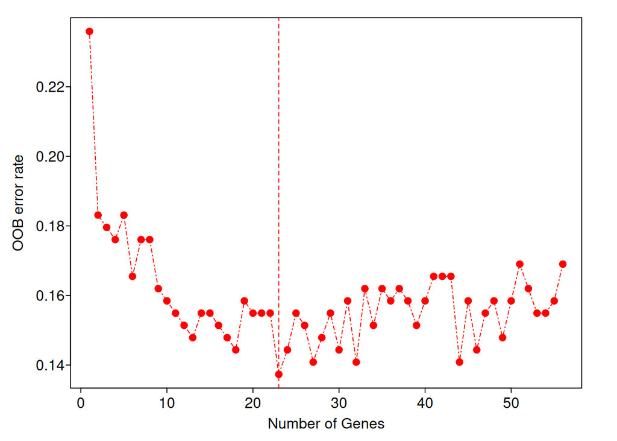

```r
#pdf("oob from swsfs.pdf",width = 6,height = 5.5)
par(bty = "o", mgp = c(1.5,.33,0), mar = c(3,4,1,2),las = 1, tcl = -.25)
plot(1:length(gene.sel),oob,
     xlab = "Number of Genes",
     ylab = "",
     type = "l",
     lty = 4,
     col = "red", # 可修改线的颜色 # The color of the line can be modified
     cex = 1.5)
mtext("OOB error rate",side = 2,line = 2.5,las = 3) # 添加y标签 # Add the y tag
points(1:length(gene.sel),oob,# 加圆圈 # with circles
       col = "red", # 可修改圆圈颜色   # can modify the color of the circle
       pch = 19)
abline(v = which.min(oob),lty = 2, col = "red") # 找到oob最小的位置添加垂直虚线  # Find the position where oob is the smallest and add a vertical dotted line
```

```r
#invisible(dev.off())

# save.image("ranger.RData")
```